# Untitled

Leo

2024-01-09

```r
#install.packages("ctsem")
library(ctsem)
library(ctsemOMX)
```

## Simulate some data (ignore this)

```r
set.seed(1)

# simulate data with 10 time points:
gm <- ctModel(LAMBDA=matrix(c(
  1,0,
  .8,0,
  0,1),ncol=2),
  MANIFESTVAR = diag(.5,3),
  DIFFUSION=matrix(c(.8,.5,0,.2),2,2),
  DRIFT=c(
    -.5,0,
    -.3,-.2),
  T0MEANS = c(20,-10),
  TRAITVAR=matrix(c(1,.7,0,.2),2,2),
  Tpoints=10,manifestNames = c('Stress','Stress2','Quality'))
```

```
## System dimensions inferred from LAMBDA
```

```
## Type "omx" is still supported but requires ctsemOMX package installation. "stanct" or "standt" are recommended types.
```

```
## T0MEANS vector spec input rowwise into 2 * 1 matrix:
```

```
##      [,1]
## [1,]  "20"
## [2,] "-10"
```

```
## DRIFT vector spec input rowwise into 2 * 2 matrix:
```

```
##      [,1]   [,2]
## [1,] "-0.5"    "0"
## [2,] "-0.3" "-0.2"
```

```r
df <-data.frame(ctGenerate(ctmodelobj = gm,n.subjects = 100,burnin = 2))
```

```
## Some free parameters in matrices set to zero!
```

# Excercises

“For this example, we have collected data from workers starting a new job. The data include measures of stress, and quality of the employees output. We are interested in a) how stress and quality change from the beginning of the job, b) whether there is any evidence for one process causing the other.” (see https://cdriver.netlify.app/post/dtbivariate/ for the full example)

## Excercise 0

Look at the data `df` and bring it in the correct format for the ctfit() function.

Here we just provide the solution feel free to just skip if you don’t want to bother with data wrangling right now.

```r
# from long format to wide format with absolute time values
df_wide0 <- ctLongToWide(datalong =df , id ="id" ,
  time = "time" , manifestNames = c('Stress', "Quality"))
```

```
## Discrete time points created:  10
```

```r
# from absolute time points to time intervals (dT1 = T1 - T0 etc. ...)
df_wide <- ctIntervalise(datawide = df_wide0, Tpoints = 10, n.manifest = 2,
                         manifestNames = c("Stress", "Quality"))
```

```
## imputedefs==FALSE (default, recommended) so setting observations with no time value to NA
```

```r
# note in this toy example every subject has the same measurement time at each
# wave for faster computations.
# In ct modelling we reflect individually varying time points and
# intervals and using this even model more complex dynamics like oscillations.

head(df_wide)
```

```
##   Stress_T0 Quality_T0 Stress_T1 Quality_T1 Stress_T2 Quality_T2 Stress_T3
## 1  7.196583  -8.016139  3.913127  -8.940450  3.517883  -8.243518 0.7853036
## 2  8.424157  -6.367648  5.186875  -6.762183  3.940901  -6.731700 2.4028387
## 3  7.506230  -7.927406  5.443343  -8.518258  3.380047  -8.907190 2.5618726
## 4  8.996550  -5.887097  5.647122  -7.304229  4.915406  -5.552340 3.9439120
## 5  7.762169  -5.415876  2.577427 -10.365073  1.549474  -8.733621 2.1191813
## 6  8.478382  -6.408571  4.361430  -7.434263  5.127386  -4.577385 4.5443919
##   Quality_T3 Stress_T4 Quality_T4  Stress_T5 Quality_T5  Stress_T6 Quality_T6
## 1  -9.168967 0.4312981  -7.610156  0.3514592  -6.760751  0.2085098  -5.570507
## 2  -6.125839 2.0286521  -6.026877  2.4442424  -5.208904  1.8695853  -4.518689
## 3  -9.185341 0.3190125  -6.905933 -1.0062852  -8.229265 -1.9472759  -7.432319
## 4  -4.549510 3.7990264  -3.761583  5.0501338  -1.643143  2.8694769  -2.578231
## 5  -7.104967 0.7910259  -5.795970  1.4359971  -3.704897  0.4056637  -4.091914
## 6  -4.670592 4.4677198  -4.221227  2.7499474  -3.543432  0.6906551  -3.637008
##    Stress_T7 Quality_T7  Stress_T8  Quality_T8  Stress_T9 Quality_T9 dT1 dT2
## 1 -0.4674126  -3.451620 -0.5701680 -4.37171220 -0.4007279 -3.8370321   1   1
## 2  1.7952979  -2.650087  2.3756833 -1.69486157  3.1815392 -0.4158248   1   1
## 3 -0.8307920  -6.221268 -0.5002181 -2.92351399 -1.5605979 -4.0164987   1   1
## 4  3.1445028  -0.812457  3.1646159 -0.08997354  1.8995697 -0.3727518   1   1
## 5 -0.6035467  -4.538801  0.4831916 -3.64616202 -0.5975131 -2.9906758   1   1
## 6  1.6032842  -2.530831  2.0295515 -2.16221805  0.9522625 -0.9880032   1   1
##   dT3 dT4 dT5 dT6 dT7 dT8 dT9
## 1   1   1   1   1   1   1   1
## 2   1   1   1   1   1   1   1
## 3   1   1   1   1   1   1   1
## 4   1   1   1   1   1   1   1
## 5   1   1   1   1   1   1   1
## 6   1   1   1   1   1   1   1
```

## Exercise 1

Set up a continuous SEM model using the `ctModel()` function that models the bivariate (ignoring `Stress2` for now) in the data frame `df_wide`.

```r
model1 <- ctModel(n.latent = 2, n.manifest = 2, Tpoints = 10,
                         manifestNames = c("Stress", "Quality"),
                         latentNames = c("Stress", "Quality"),

                         # loading matrix (1 on diagonal, 0 on off-diagonal):
                         LAMBDA = diag(2),
                          # Drift and the other matrices are
                         # not necessary to explicitly specify unless you want to
                         # change/restrict something:
                         DRIFT = c('a_Stress','a_Stress_Quality',
                                   'a_Quality_Stress','a_Quality'))
```

```
## Type "omx" is still supported but requires ctsemOMX package installation. "stanct" or "standt" are recommended types.
```

```
## DRIFT vector spec input rowwise into 2 * 2 matrix:
```

```
##      [,1]               [,2]
## [1,]         "a_Stress" "a_Stress_Quality"
## [2,] "a_Quality_Stress"        "a_Quality"
```

## Exercise 2

Fit the model to the data using the `ctfit()` function.

```r
modelfit1<- ctFit(datawide = df_wide, ctmodelobj = model1)
```

```
## dat not specified, using datawide
```

```
## wide format data detected
```

```
## Running ctsemCarefulFit with 16 parameters
```

```
## Running ctsem with 16 parameters
```

```
##
## Beginning initial fit attempt
```

```
## Running ctsem with 16 parameters
```

```
##
##  Lowest minimum so far:  5590.85680796767
```

```
##
## Solution found
```

```
##
##  Solution found!  Final fit=5590.8568 (started at 7465.5532)  (1 attempt(s): 1 valid, 0 errors)
```

## Exercise 3

Plot the resulting fit for the auto and cross-effects (put `wait = F`)

```
## Plotting fit
```

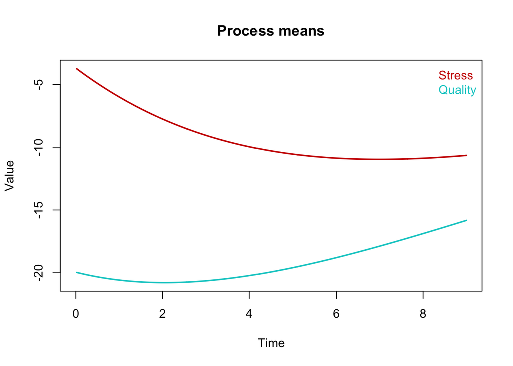

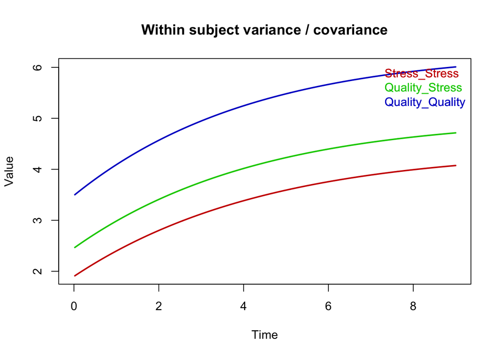

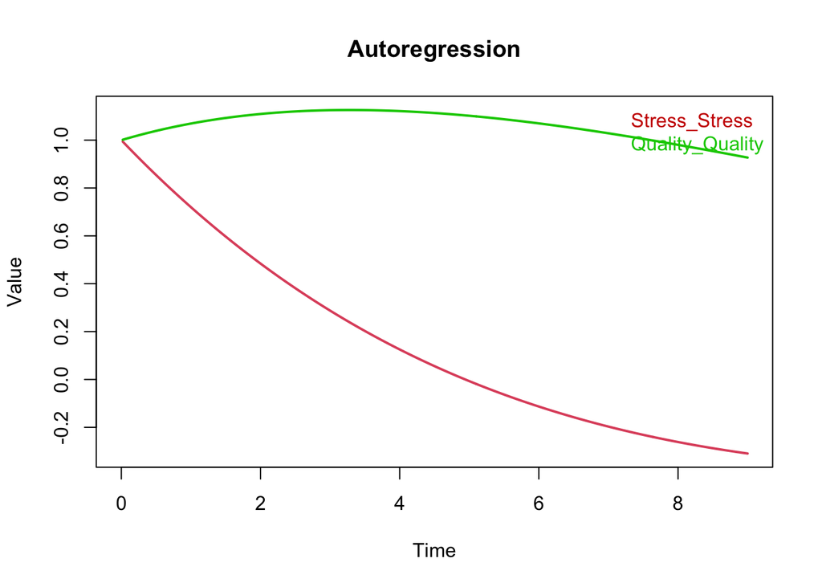

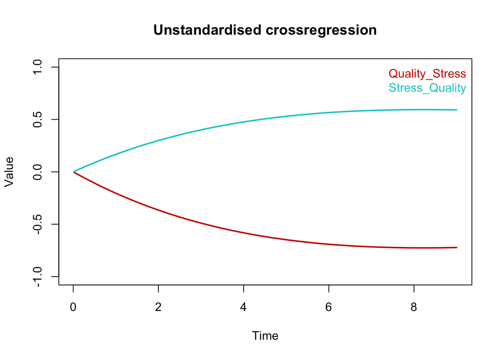

```r
plot(modelfit1, wait = FALSE)
```

## Exercise 4

Look at the fit summary (`summary(example1fit)`) and the plots. Interpret the model parameters and its fit in your own words. Do Stress and Quality influence each other? How does this change as a function of the time interval considered? Which variable is more stable?

```r
summary(modelfit1)
```

```
## $LAMBDA
##         Stress Quality
## Stress       1       0
## Quality      0       1
##
## $DRIFT
##             Stress    Quality
## Stress  -0.3040758 0.18642898
## Quality -0.2278372 0.08583657
##
## $MANIFESTVAR
##           Stress  Quality
## Stress  0.229633 0.000000
## Quality 0.000000 0.301968
##
## $MANIFESTMEANS
##          [,1]
## [1,] 11.18719
## [2,] 13.22007
##
## $CINT
##         [,1]
## Stress     0
## Quality    0
##
## $DIFFUSION
##            Stress  Quality
## Stress  0.7923612 0.908563
## Quality 0.9085630 1.193901
##
## $T0VAR
##           Stress  Quality
## Stress  1.900413 2.455527
## Quality 2.455527 3.488400
##
## $T0MEANS
##               [,1]
## Stress   -3.699972
## Quality -19.957995
##
```

[output cut: 48 more lines]

```
## $omxsummary$observedStatistics
## [1] 230
##
## $omxsummary$<NA>
## NULL
##
## $omxsummary$degreesOfFreedom
## [1] 214
##
## $omxsummary$Minus2LogLikelihood
## [1] 5590.857
##
##
## $message
## [1] "For additional summary matrices and raw OpenMx parameter output, use argument verbose=TRUE"
```

### Cross-effects

Cross effects are interpreted analogous to regression effects: An one unit increase of Stress leads to a 0.23 unit decrease in Quality. A one unit increase of Quality leads to an 0.19 unit increase in Stress.

### Auto-effects

Auto effects are best interpreted in their converted form (by plotting) as solutions to the stochastic differential model equation as a function of the time interval.

However in general for the diagonal drift coefficients one can say: The closer to 0 the drift parameter the more stable the process of the respective construct. The more negative a parameter gets the less stable the process. (This can be understood when looking at the solution to the stochastic differential equation)

Here we see Quality as a more stable construct across different time intervals. While the auto-regressive effect of Stress decreases the longer the respective time interval.

# Excercise 5 (optional)

Extend the model to account for unit heterogeneity by modelling intersubjective variability (random intercept) of manifest variables. Hint: simply add the `TRAITVAR = "auto"` argument to the model. Use the plot function to graphically compare the model to the previous model. How does your interpretation change?

```r
traitmodel <- ctModel(n.latent = 2, n.manifest = 2, Tpoints = 10,
                         manifestNames = c("Stress", "Quality"),
                         latentNames = c("Stress", "Quality"),
                         DRIFT = c('a_Stress','a_Stress_Quality',
                             'a_Quality_Stress','a_Quality'),
                         LAMBDA = diag(2),
                         TRAITVAR = "auto")
```

```
## Type "omx" is still supported but requires ctsemOMX package installation. "stanct" or "standt" are recommended types.
```

```
## DRIFT vector spec input rowwise into 2 * 2 matrix:
```

```
##      [,1]               [,2]
## [1,]         "a_Stress" "a_Stress_Quality"
## [2,] "a_Quality_Stress"        "a_Quality"
```

```r
traitfit <- ctFit(datawide = df_wide, ctmodelobj = traitmodel)
```

```
## dat not specified, using datawide
```

```
## wide format data detected
```

```
## Running ctsemCarefulFit with 19 parameters
```

```
## Running ctsem with 19 parameters
```

```
##
## Beginning initial fit attempt
```

```
## Running ctsem with 19 parameters
```

```
##
##  Lowest minimum so far:  5481.5739845122
```

[output not shown]

```
##
## Beginning fit attempt 1 of at maximum 5 extra tries
```

```
## Running ctsem with 19 parameters
```

```
##
##  Lowest minimum so far:  5481.57398438405
```

```
##
## Solution found
```

```
##
##  Solution found!  Final fit=5481.574 (started at 6242.2556)  (2 attempt(s): 2 valid, 0 errors)
```

```
## Plotting fit
```

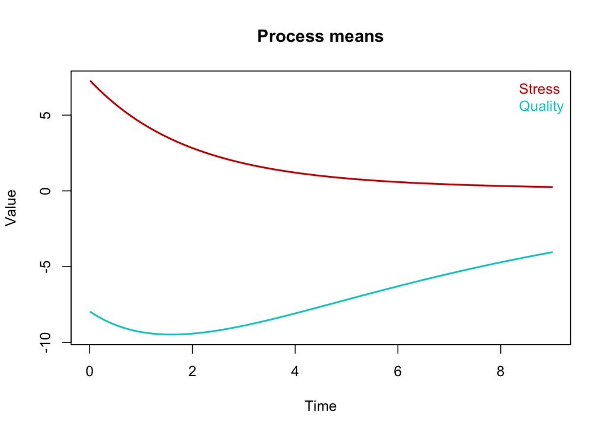

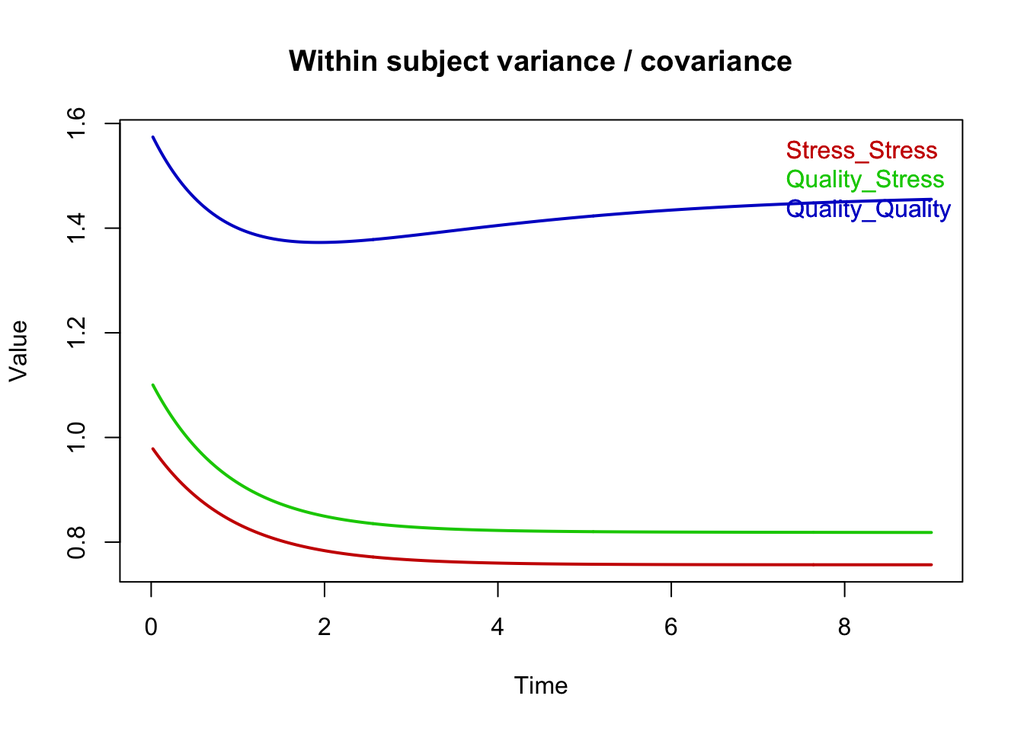

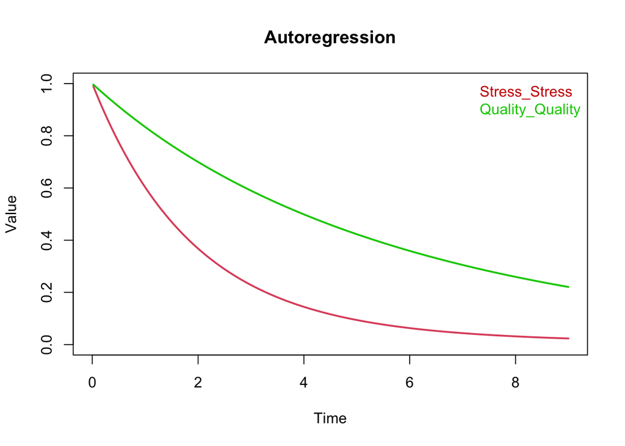

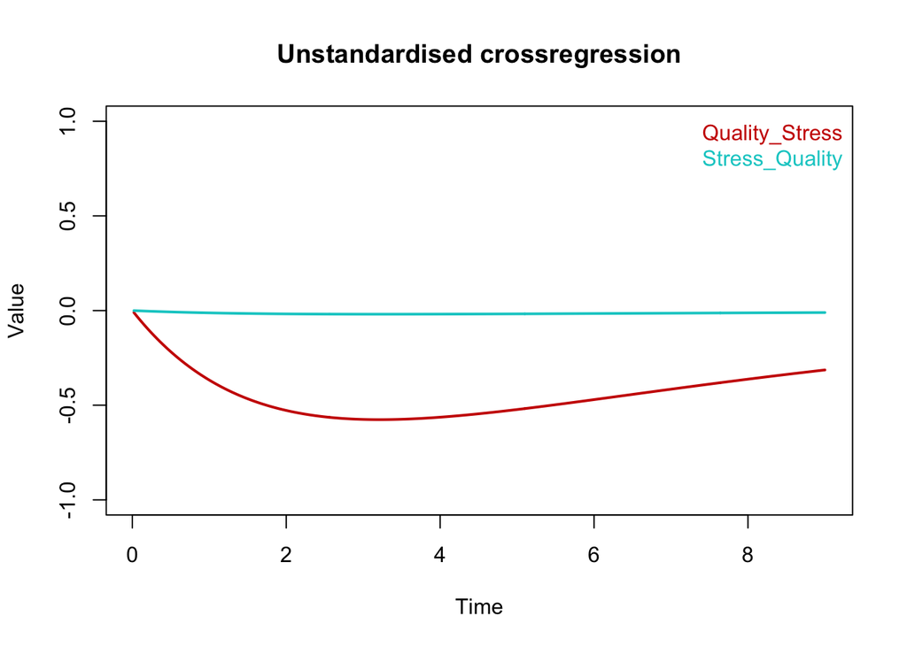

```r
plot(traitfit, wait = FALSE)
```

# Excercise 6 (optional)

Extend the `LAMBDA` function to include the second Stress indicator `Stress2`

first run this to extend

```r
# from long format to wide format with absolute time values
df_wide1 <- ctLongToWide(datalong =df , id ="id" ,
  time = "time" , manifestNames = c('Stress', "Stress2", "Quality"))
```

```
## Discrete time points created:  10
```

```r
# from absolute time points to time intervals (dT1 = T1 - T0 etc. ...)
df_wide2 <- ctIntervalise(datawide = df_wide1, Tpoints = 10, n.manifest = 3,
                         manifestNames = c("Stress", "Stress2", "Quality"))
```

```
## imputedefs==FALSE (default, recommended) so setting observations with no time value to NA
```

```r
# note in this toy example every subject has the same measurement time at each
# wave for faster computations.
# In ct modelling we reflect individually varying time points and
# intervals and using this even model more complex dynamics like oscillations.

head(df_wide2)
```

```
##   Stress_T0  Stress2_T0 Quality_T0 Stress_T1 Stress2_T1 Quality_T1 Stress_T2
## 1  7.196583 -0.02690252  -8.016139  3.913127 -0.1971450  -8.940450  3.517883
## 2  8.424157  0.27924321  -6.367648  5.186875 -0.6123063  -6.762183  3.940901
## 3  7.506230 -0.31063335  -7.927406  5.443343  0.2125502  -8.518258  3.380047
## 4  8.996550 -0.02235457  -5.887097  5.647122 -0.3151502  -7.304229  4.915406
## 5  7.762169 -0.20376429  -5.415876  2.577427 -0.2903072 -10.365073  1.549474
## 6  8.478382 -0.14474968  -6.408571  4.361430  0.4580097  -7.434263  5.127386
##   Stress2_T2 Quality_T2 Stress_T3  Stress2_T3 Quality_T3 Stress_T4 Stress2_T4
## 1 0.38158787  -8.243518 0.7853036  0.34848169  -9.168967 0.4312981 -0.3537476
## 2 0.02105794  -6.731700 2.4028387 -0.32729232  -6.125839 2.0286521  0.4550871
## 3 0.44321133  -8.907190 2.5618726 -0.12751352  -9.185341 0.3190125  0.1037692
## 4 0.90157095  -5.552340 3.9439120  0.09859672  -4.549510 3.7990264 -1.4444603
## 5 0.47259248  -8.733621 2.1191813 -0.19505933  -7.104967 0.7910259 -0.7131287
## 6 0.94373723  -4.577385 4.5443919  0.18998134  -4.670592 4.4677198  0.2981171
##   Quality_T4  Stress_T5  Stress2_T5 Quality_T5  Stress_T6  Stress2_T6
```

[output cut: 27 more lines]

```r
factormodel <- ctModel(
  Tpoint = 10,
  manifestNames = c('Stress','Stress2','Quality'),
  # Drift and Diffusion and other matrices are constructed by default

  #factor loadings / measurement structure:
  #now with estimated factor loading for Stress2 variable (the matrix is
  #filled rowise)
  LAMBDA = matrix(c(1, "stressLoading", 0, 0, 0, 1), ncol = 2))
```

```
## System dimensions inferred from LAMBDA
```

```
## Type "omx" is still supported but requires ctsemOMX package installation. "stanct" or "standt" are recommended types.
```

```r
factormodel$LAMBDA
```

```
##         eta1            eta2
## Stress  "1"             "0"
## Stress2 "stressLoading" "0"
## Quality "0"             "1"
```

```r
factorfit <- ctFit(datawide = df_wide2, ctmodelobj = factormodel)
```

```
## dat not specified, using datawide
```

```
## wide format data detected
```

```
## Running ctsemCarefulFit with 19 parameters
```

```
## Running ctsem with 19 parameters
```

```
##
## Beginning initial fit attempt
```

```
## Running ctsem with 19 parameters
```

```
##
##  Lowest minimum so far:  7117.90218543868
```

```
##
## Solution found
```

```
##
##  Solution found!  Final fit=7117.9022 (started at 9221.2083)  (1 attempt(s): 1 valid, 0 errors)
```

```r
summary(factorfit)
```

```
## $LAMBDA
##                eta1 eta2
## Stress  1.000000000    0
## Stress2 0.002977787    0
## Quality 0.000000000    1
##
## $DRIFT
##            eta1       eta2
## eta1 -0.3040668 0.18642089
## eta2 -0.2278478 0.08581902
##
## $MANIFESTVAR
##            Stress   Stress2   Quality
## Stress  0.2297604 0.0000000 0.0000000
## Stress2 0.0000000 0.2695951 0.0000000
## Quality 0.0000000 0.0000000 0.3017693
##
## $MANIFESTMEANS
##             [,1]
## [1,] 11.18238267
## [2,]  0.03455169
## [3,] 13.21257695
##
## $CINT
##      [,1]
## eta1    0
## eta2    0
##
## $DIFFUSION
##           eta1      eta2
## eta1 0.7922453 0.9086308
## eta2 0.9086308 1.1942247
##
## $T0VAR
##          eta1     eta2
## eta1 1.900423 2.455586
## eta2 2.455586 3.488469
##
## $T0MEANS
##            [,1]
```

[output cut: 54 more lines]

```
## $omxsummary$observedStatistics
## [1] 495
##
## $omxsummary$<NA>
## NULL
##
## $omxsummary$degreesOfFreedom
## [1] 476
##
## $omxsummary$Minus2LogLikelihood
## [1] 7117.902
##
##
## $message
## [1] "For additional summary matrices and raw OpenMx parameter output, use argument verbose=TRUE"
```